# 1.Length biased gene sets

Generate lists of mouse genes biased by the length of the genes.

## Lengths of all genes

The gene info file contains the lengths of all the genes in the mouse genome Mus_musculus.GRCm38.94. These can be plotted so that some thresholds for length categories can be determined. Plot out the length distribution for all the genes.

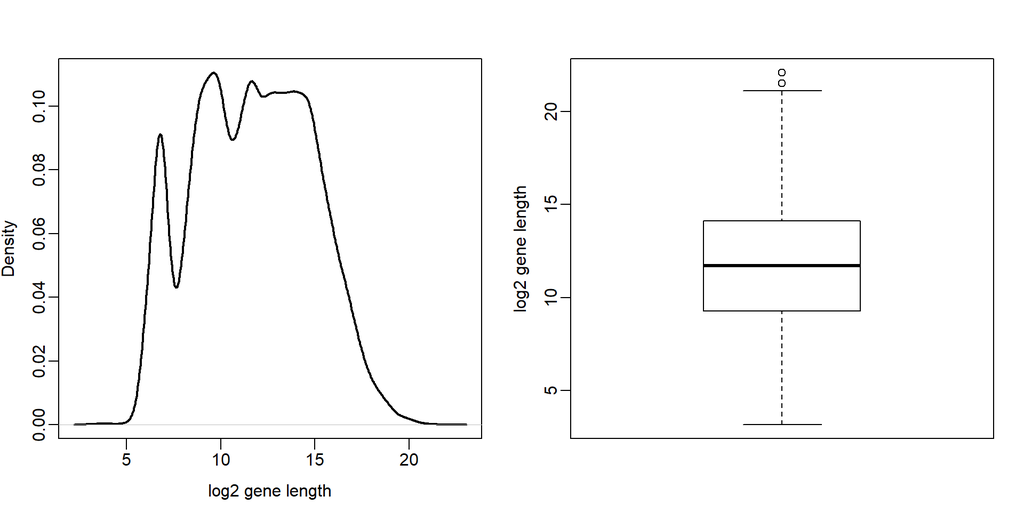

This data is displayed on a log scale as there are some very long genes that distort the graph if it is plotted on a linear scale. The plot shows a set of short genes between 32 and 194.0117205 (~5-7.5 on log2 scale). This provides a natural set of lengths to use, and can be split into a “very short” and a “short1” category. We’ll also take some of the genes that are slightly longer but are below the next peak in the distribution. As the distribution of lengths for the long genes is smooth, this provides no obvious thresholds to select, so we can take the top 5% and 10% of lengths.

#### Select gene length thresholds.

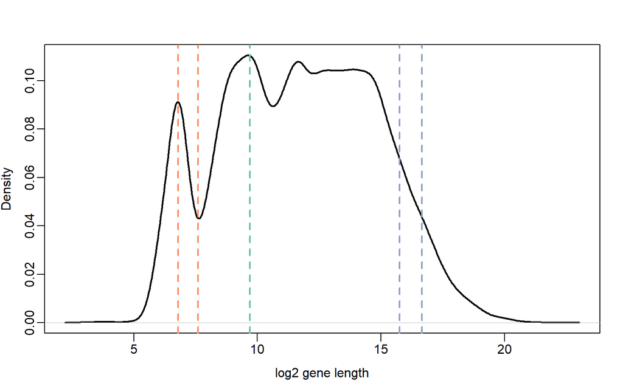

## Thresholds

```
very_short     short1     short2       long  very_long
   6.80000    7.60000    9.70000   15.75344   16.66262
```

The number of genes that remain after filtering for each length category.

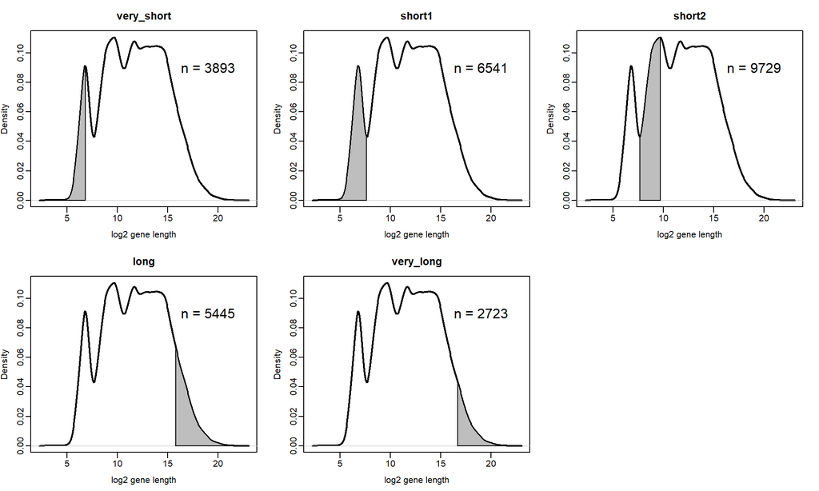

## Generating the biased gene lists

Check they all look right

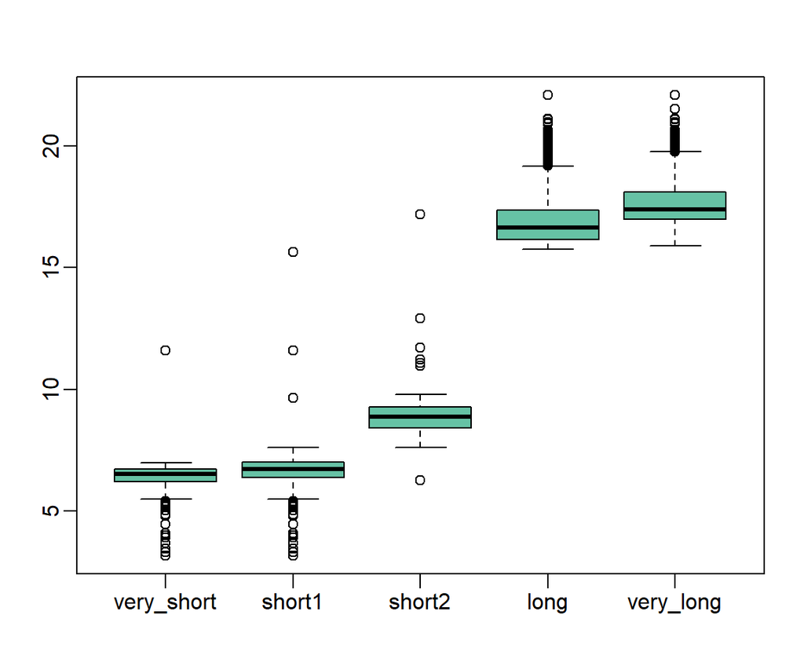

The odd gene that doesn’t fall within the expected size range may be due to name duplication.

## GO overrepresentation analysis

Run the gene lists through a GO overrepresentation analysis.

We don’t want to run the GO analysis each time the document is knitted as it takes too long. The code was run once and the data saved as an .rda object that can be quickly loaded in to the R session.

See how many significant categories were returned.

The number of gene sets that returned significant results from the GO overrepresentation analysis

```
very_short     short1     short2       long  very_long
        89         47          9        100        100
```

The bean plots show the number of categories returned from each gene list. The null results have been removed.

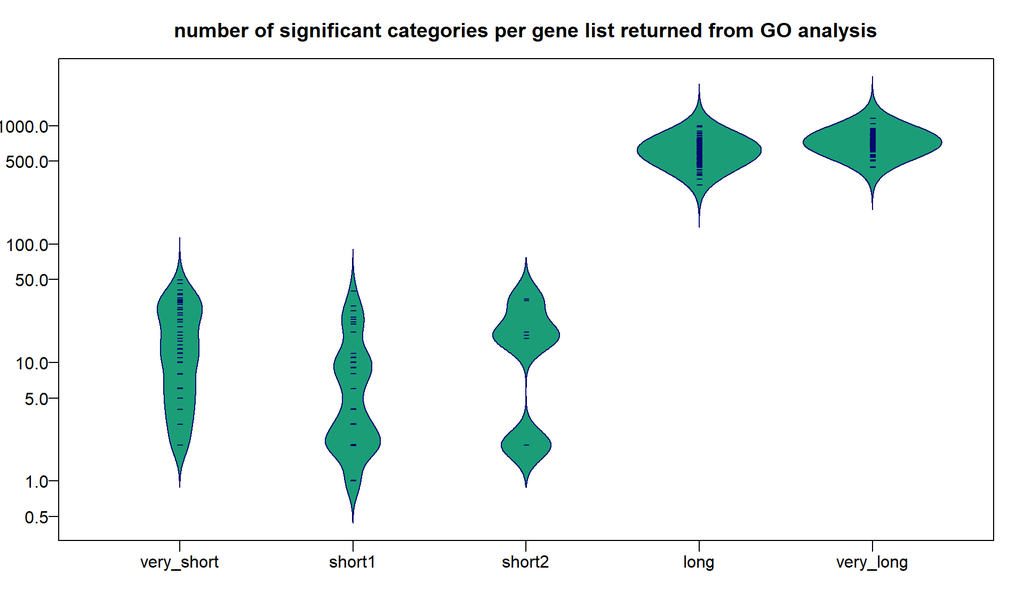

Plot how many times a category appeared.

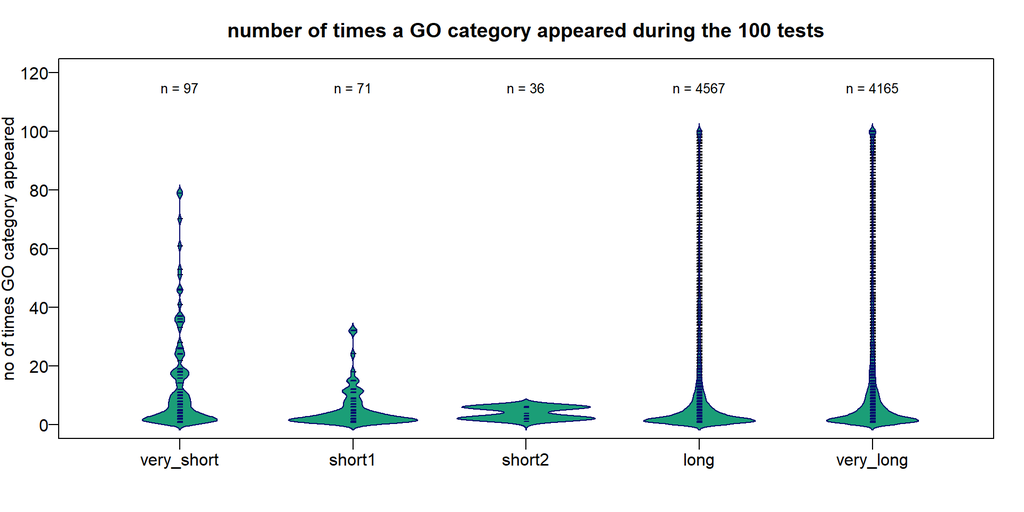

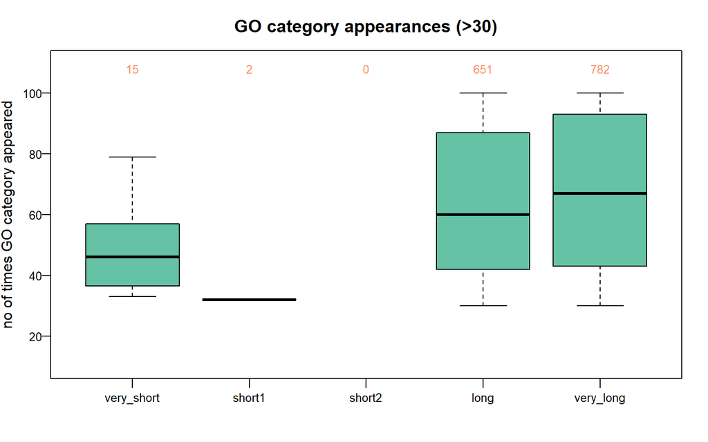

Replot just showing the data for categories that appeared >= 30 times

Now we could do with some stats to pick a cutoff for the number of times a category appears. Let’s just select an arbitrary value for now….

Create a dataset that contains these suspect set of categories

```
very_short     short1     short2       long  very_long
        15          2          0        651        782
```

```
[1] 2
[1] 609
```

```
[1] 609
```

There are 2 overlapping categories between very_short and short1.  
There are 609 overlapping categories between very_long and long.

The duplicate terms will be removed from the more stringent categories.

```
very_short     short1     short2       long  very_long
        13          2          0        651        173
```

Rename “short1” to “short”

```
very_short      short       long  very_long
        13          2        651        173
```

Laura Biggins

2019-10-24